# microbiome_processing

Ciel Baumann

2026-04-28

### Import packages

```r
#install.packages("BiocManager")
#BiocManager::install("phyloseq")
#BiocManager::install("Biostrings")
#install.packages("ggplot2")
library(phyloseq, quietly=TRUE, warn.conflicts=FALSE); packageVersion("phyloseq")
```

```
## [1] '1.50.0'
```

```r
library(Biostrings, quietly=TRUE, warn.conflicts=FALSE); packageVersion("Biostrings")
```

```
## [1] '2.74.0'
```

```r
library(ggplot2, quietly=TRUE, warn.conflicts=FALSE); packageVersion("ggplot2")
```

```
## [1] '3.5.1'
```

### Read in data

```r
# Read in the seqtab.nochim table. The column names are the ASV sequences.
dadaFolder="/scratch/projects/RCH-BIOL337/BIOL337_2026/MICROBIOME/DATA/fullTableData/WORK_fullDATASET/"
seqtab.nochim=readRDS(file=paste0(dadaFolder,"/","seqtab.dada.rds"))

# Read in pipeline tracking table
tracking=readRDS(file=paste0(dadaFolder,"/","tracking.dada.rds"))
gtdbTaxa=readRDS(file=paste0(dadaFolder,"/","gtdbTaxa.dada.rds"))

# Read in metadata (SraRunTable)
metadata <- read.csv(file="/scratch/projects/RCH-BIOL337/BIOL337_2026/MICROBIOME/DATA/SraRunTable.csv")
```

### Filter ASVs and Samples

#### Filter ASVs

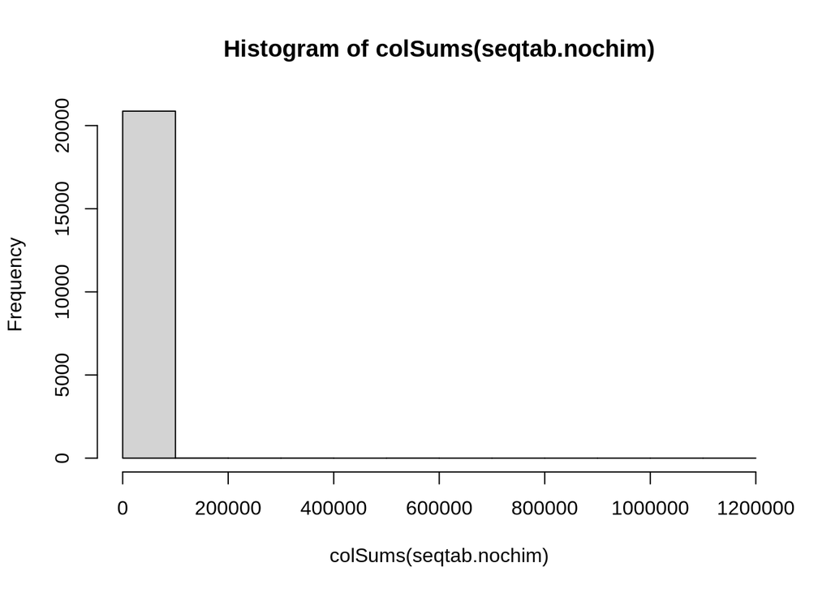

```r
hist(colSums(seqtab.nochim)) # Column sums (i.e., number of reads per ASV) before filtration
```

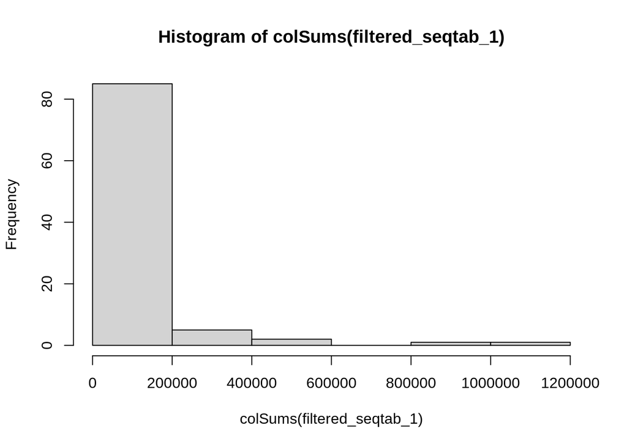

```r
keepASVs <- which(colSums(seqtab.nochim) >= 0.001*sum(seqtab.nochim))
filtered_seqtab_1 <- seqtab.nochim[,keepASVs]
hist(colSums(filtered_seqtab_1)) # Column sums after filtration
```

#### Filter Samples

“… each sample was standardised to 1400 sequence reads using the SRS function in the SRS package (Heidrich et al., 2021; ver 0.2.3), which resulted in the removal of two further samples with low sequencing depth” (Hoffbeck et al., 2024). Although we are not following the exact standardisation process they used, I will still remove samples with less than 1400 sequence reads.

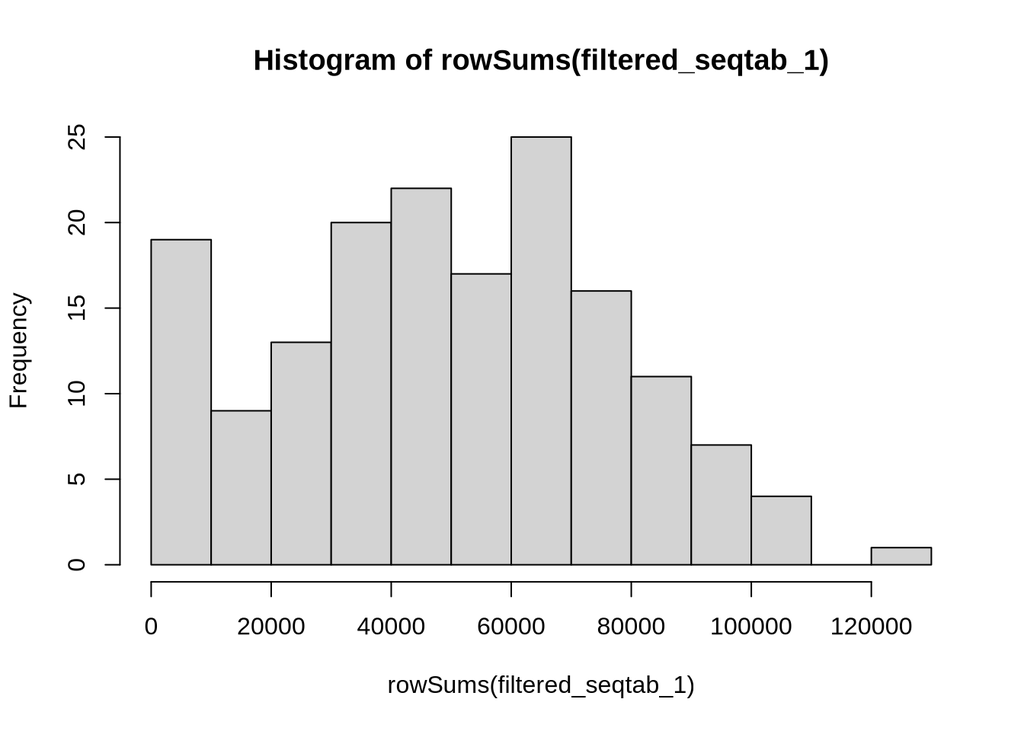

```r
hist(rowSums(filtered_seqtab_1)) # Row sums (i.e., number of reads per sample) before filtration
```

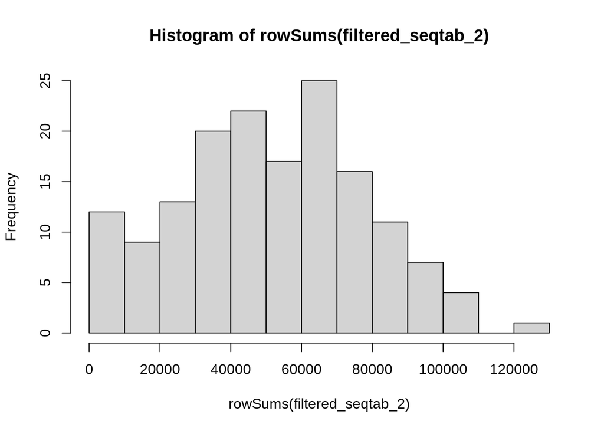

```r
keepSamples<-which(rowSums(filtered_seqtab_1)>=1400) # This removes samples with less than 1400 reads
filtered_seqtab_2 <-filtered_seqtab_1[keepSamples,]
hist(rowSums(filtered_seqtab_2)) # Row sums after filtration
```

#### Get new matrix dimensions

There are now 157 samples (rows) and 94 ASVS (columns).

```r
filtered_seqtab <- filtered_seqtab_2
dim(filtered_seqtab)
```

```
## [1] 157  94
```

### Set up a Phyloseq object

#### Initialise the Phyloseq object

```r
otu_mat <- otu_table(filtered_seqtab, taxa_are_rows = FALSE) # Operational Taxonomic Unit table
tax_mat<-tax_table(gtdbTaxa$tax) # Use taxonomies assigned via GTDB database sequences
sampleData<-metadata[which(!is.na(match(metadata$Run,names(keepSamples)))),]
rownames(sampleData)<-sampleData$Run # Need to ensure rownames of sample data match library names in ASV table
sample_mat=sample_data(sampleData) # sample matrix

PS_object <- phyloseq(otu_mat, tax_mat, sample_mat) # Phyloseq object
PS_object
```

```
## phyloseq-class experiment-level object
## otu_table()   OTU Table:         [ 94 taxa and 157 samples ]
## sample_data() Sample Data:       [ 157 samples by 41 sample variables ]
## tax_table()   Taxonomy Table:    [ 94 taxa by 7 taxonomic ranks ]
```

#### Remove mock community samples

```r
PS_object <- prune_samples(sample_data(PS_object)$Sample.Name != "Mock_community", PS_object)
```

#### Rename ASVs from DNA sequence to ASV1, ASV2, …

```r
dna <- Biostrings::DNAStringSet(taxa_names(PS_object)) # Store DNA sequences in a Biostrings object
names(dna) <- taxa_names(PS_object) # Link taxa names to DNA sequences
PS_object <- merge_phyloseq(PS_object, dna) # Stores the DNA sequences within the Phyloseq object
taxa_names(PS_object) <- paste0("ASV", seq(ntaxa(PS_object))) # Overwrite sequences with ASV1, ASV2, ...
PS_object
```

```
## phyloseq-class experiment-level object
## otu_table()   OTU Table:         [ 94 taxa and 156 samples ]
## sample_data() Sample Data:       [ 156 samples by 41 sample variables ]
## tax_table()   Taxonomy Table:    [ 94 taxa by 7 taxonomic ranks ]
## refseq()      DNAStringSet:      [ 94 reference sequences ]
```

### Create Phyloseq Plots

#### Visualise Alpha-Diversity

The red dot is a sample with missing metadata. In both plots, adults tend to have higher alpha-diversity scores than subadults, but note the sample size discrepancy. The alpha-diversity scores also show generally skewed distributions in both plots, with the peaks at a higher score. These distributions look fairly similar across all sites.

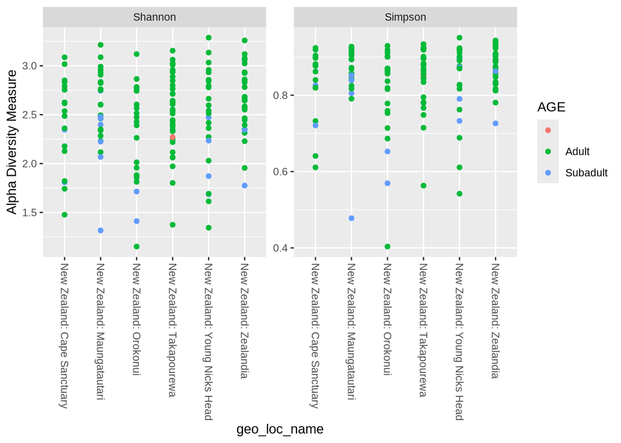

```r
plot_richness(PS_object, x="geo_loc_name", measures=c("Shannon", "Simpson"), color="AGE")
```

#### Ordination Plot

```r
# Transform sample abundance counts to relative proportions within a sample.
# Each sample is a vector where each element represents a given ASV, and the
# value of each element is the number of counts for that ASV. Dividing the
# sample vector by the sum of its counts will yield a vector representing the
# proportions of each ASV within that sample.
PS_object.prop <- transform_sample_counts(
  PS_object, function(sample_counts) (sample_counts)/sum(sample_counts)
)
ord.nmds.bray <- ordinate(PS_object.prop, method = "NMDS", distance="bray")
```

```
## *** Best solution was not repeated -- monoMDS stopping criteria:
##      5: no. of iterations >= maxit
##     15: stress ratio > sratmax
```

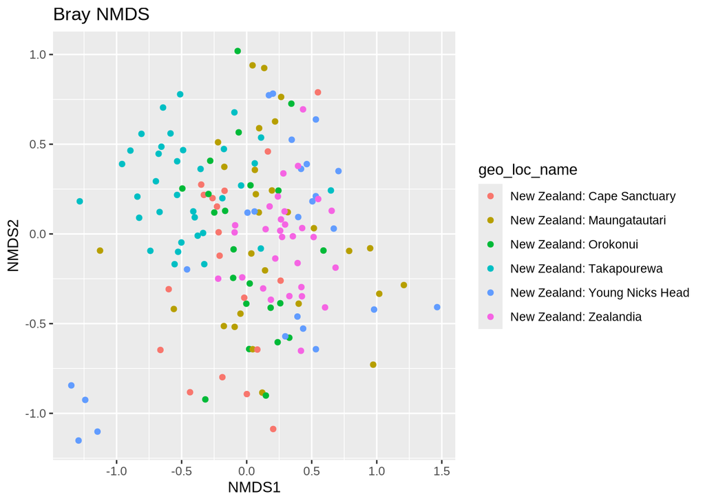

```r
plot_ordination(PS_object.prop, ord.nmds.bray, color="geo_loc_name", title="Bray NMDS")
```

```r
# The dots appear to cluster by location and have significnt overlap. Some more scattered than others.
```

#### Create Phyla and Genera Bar Plots

In non-standardised data, it is possible that excessive number of reads within a sample can bias the results to weigh that sample’s results more heavily. To address this, the authors standardised the number of reads to 1400 reads per sample (but not sure how exactly - a random subset? averaging?), whereas we applied a simple transformation to get the proportions of ASVs within a sample in the previous step.

##### Create Phyla Bar Plot

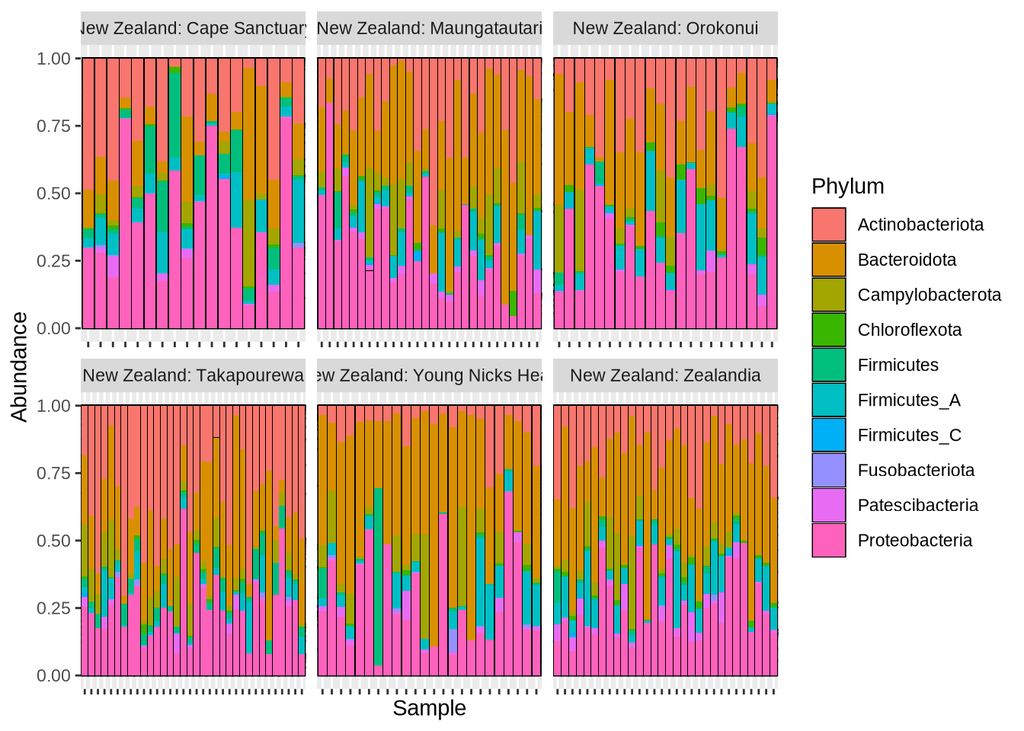

```r
plot_bar(PS_object.prop, fill="Phylum") +
  facet_wrap(~geo_loc_name, scales="free_x") +
  theme(axis.text.x = element_blank()) +
  geom_bar(stat="identity")
```

##### Create Genera Bar Plot

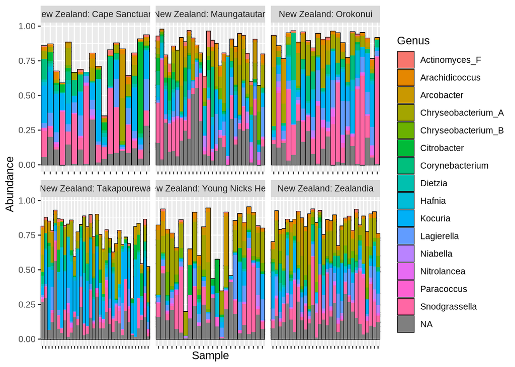

```r
# For clarity, only use top 30 ASVs for the genus plot
top30 <- names(sort(taxa_sums(PS_object.prop), decreasing=TRUE))[1:30]
PS_object.prop.top30 <- prune_taxa(top30, PS_object.prop)

# Plot genus plot
plot_bar(PS_object.prop.top30, fill="Genus") +
  facet_wrap(~geo_loc_name, scales="free_x") +
  theme(axis.text.x = element_blank()) +
  geom_bar(stat="identity")
```